# Abundance change at different levels of predation

Faith Jones

16 June 2017

Here i present the mixed model results for change in the abundance of predators. There are three levels of predation: Wide (group 2 and 3 species), Middle (group2) and Narrow(Hoplias and Crenicichla). Only teh data from July/august is incuded so I could use the 2016 data. Also the survey eatken in 2010 is removed sure to sampling differences.

# Narrow level predation definition

Here is the plot showing trendlines for each sites, using the linear model part of ggplot

```r
head(FishDataTotAb)
```

```
##      site Year BiomasSiteSum AbundanceSum meanYear meanCentredYear
## 1 Acono d 2011       1572.66            6   2013.5            -2.5
## 2 Acono d 2012        870.00            8   2013.5            -1.5
## 3 Acono d 2013       1599.30            3   2013.5            -0.5
## 4 Acono d 2014       1589.12            3   2013.5             0.5
## 5 Acono d 2015       1253.90            6   2013.5             1.5
## 6 Acono d 2016       1900.55            7   2013.5             2.5
##      logAb
## 1 2.807355
## 2 3.169925
## 3 2.000000
## 4 2.000000
## 5 2.807355
## 6 3.000000
```

```r
predOrder <- data.frame(FishDataTotAb%>% #det the oder of which sites are highest predation for plotting
  group_by(site) %>%
  summarise(meanAb = mean(AbundanceSum)) %>%
  arrange(meanAb)%>%
  mutate(orderAb = c(1:16)))

plotNAbData <- merge(FishDataTotAb, predOrder, by = "site")

plotNAbData <- plotNAbData[order(plotNAbData$orderAb),]
plotNAbData$reoderedSite <- reorder(plotNAbData$site, plotNAbData$orderAb)

getPalette <-  colorRampPalette(c("blue", "red"))
getPalette(16)
```

```
##  [1] "#0000FF" "#1100EE" "#2200DD" "#3300CC" "#4400BB" "#5500AA" "#660099"
##  [8] "#770088" "#880077" "#990066" "#AA0055" "#BB0044" "#CC0032" "#DD0021"
## [15] "#EE0010" "#FF0000"
```

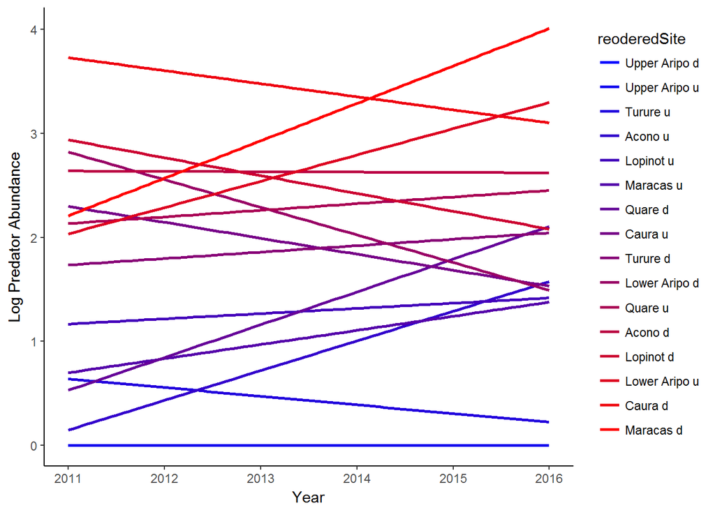

```r
NarrowAdundance <- ggplot(aes(x = Year, y = logAb, colour = reoderedSite ),data = plotNAbData)
NarrowAdundance +
  geom_smooth(se = FALSE, method = "lm")+
    theme_classic()+
    labs(y = "Log Predator Abundance")   +
  scale_colour_manual(values = getPalette(16))
```

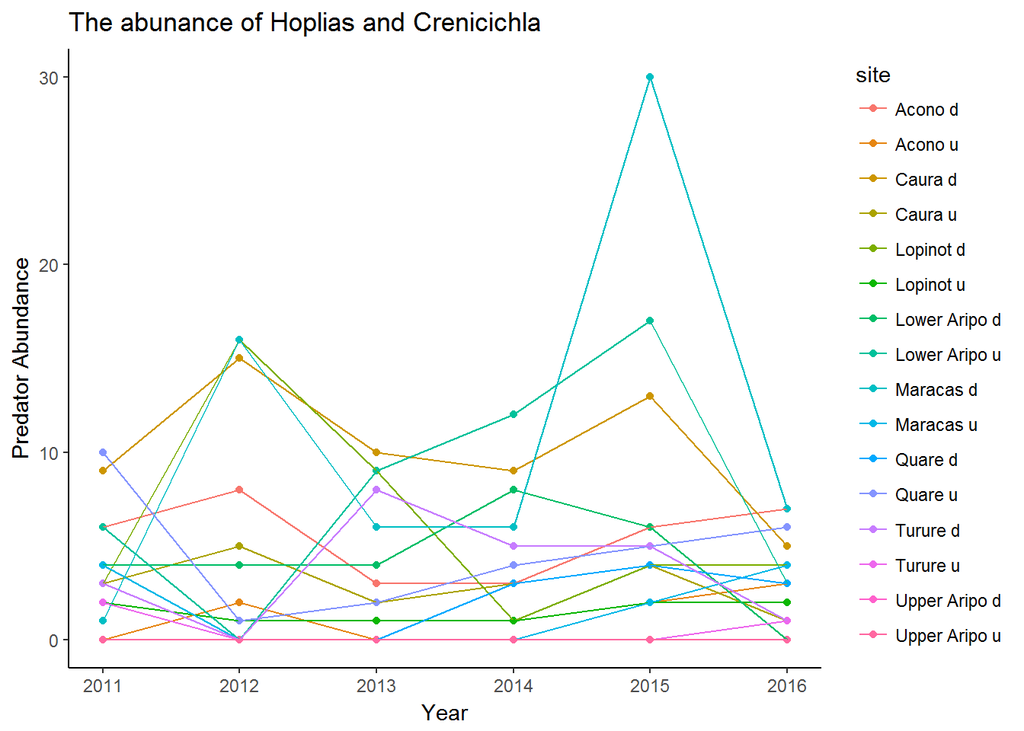

```r
AbPlot <- ggplot(FishDataTotAb, aes(x = Year, y = AbundanceSum, col = site, group = site))
AbPlot + geom_point() +
    geom_line() +
    theme_classic() +
    labs(title="The abunance of Hoplias and Crenicichla", y = "Predator Abundance")
```

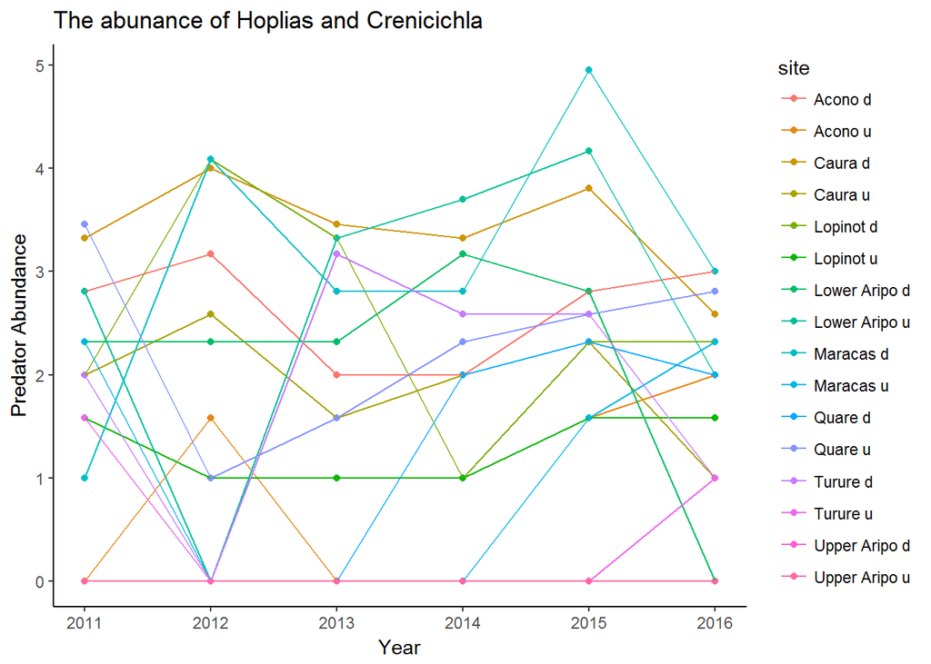

```r
AbPlotLog <- ggplot(FishDataTotAb, aes(x = Year, y = logAb, col = site, group = site))
AbPlotLog + geom_point() +
    geom_line() +
    theme_classic() +
    labs(title="The abunance of Hoplias and Crenicichla", y = "Predator Abundance")
```

Next is the mixed model results and plot of slopes of the sites

```r
AbM1 <- lmer(logAb  ~ meanCentredYear + (meanCentredYear|site), data = FishDataTotAb)
summary(AbM1)
```

```
## Linear mixed model fit by REML ['lmerMod']
## Formula: logAb ~ meanCentredYear + (meanCentredYear | site)
##    Data: FishDataTotAb
##
## REML criterion at convergence: 291.9
##
## Scaled residuals:
##      Min       1Q   Median       3Q      Max
## -2.71020 -0.54782  0.08909  0.59495  2.14378
##
## Random effects:
##  Groups   Name            Variance Std.Dev. Corr
##  site     (Intercept)     0.984279 0.992108
##           meanCentredYear 0.000034 0.005831 -1.00
##  Residual                 0.840789 0.916945
## Number of obs: 96, groups:  site, 16
##
## Fixed effects:
##                 Estimate Std. Error t value
## (Intercept)      1.72050    0.26510   6.490
## meanCentredYear  0.04512    0.05482   0.823
##
## Correlation of Fixed Effects:
##             (Intr)
## meanCntrdYr -0.025
```

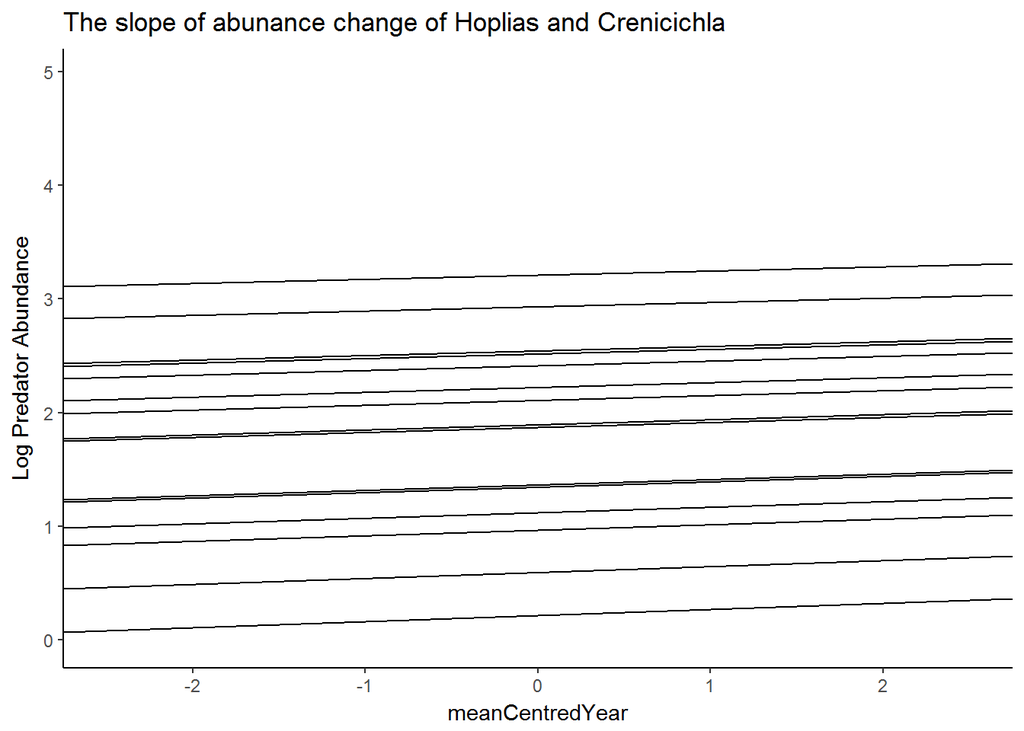

```r
#plot slopes of sites
AbM1_Lines <- coef(AbM1)$site[c(1:2)] # get slope and intercept of each line in model 3
names(AbM1_Lines) <- c("intercept", "slope")

m3.plot <- ggplot(data = FishDataTotAb, aes(x = meanCentredYear, y = logAb)) # plot of model with varying intercept but not slope, but only main slope shown
m3.plot + geom_blank() +
    theme_classic() +
    geom_abline(slope = AbM1_Lines$slope, intercept = AbM1_Lines$intercept) +
    labs(title="The slope of abunance change of Hoplias and Crenicichla", y = "Log Predator Abundance")
```

## Middle level predation definition

Here is the plot showing trendlines for each sites, using the linear model part of ggplot

```r
predOrderm <- data.frame(FishDataTotAbm %>% #det the oder of which sites are highest predation for plotting
  group_by(site) %>%
  summarise(meanAb = mean(AbundanceSum)) %>%
  arrange(meanAb) %>%
  mutate(orderAb = c(1:16)))

plotNAbDatam <- merge(FishDataTotAbm, predOrderm, by = "site")

plotNAbDatam <- plotNAbDatam[order(plotNAbDatam$orderAb),]
plotNAbDatam$reoderedSite <- reorder(plotNAbDatam$site, plotNAbDatam$orderAb)

getPalette <-  colorRampPalette(c("blue", "red"))
getPalette(16)
```

```
##  [1] "#0000FF" "#1100EE" "#2200DD" "#3300CC" "#4400BB" "#5500AA" "#660099"
##  [8] "#770088" "#880077" "#990066" "#AA0055" "#BB0044" "#CC0032" "#DD0021"
## [15] "#EE0010" "#FF0000"
```

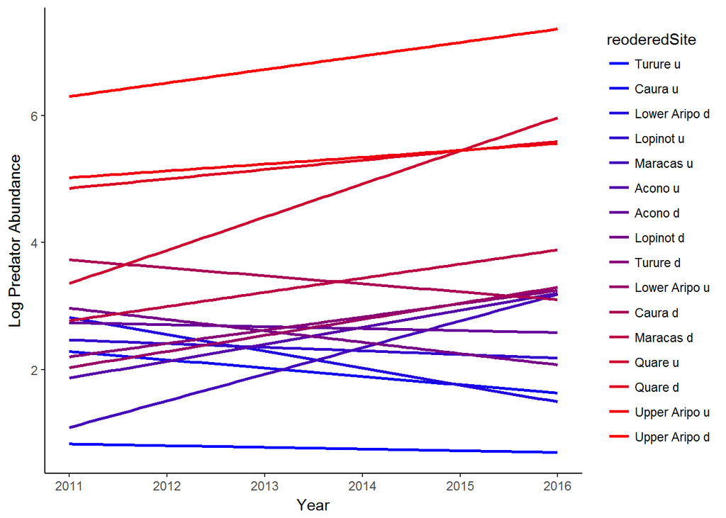

```r
MiddleAdundance <- ggplot(aes(x = Year, y = logAb, colour = reoderedSite),data = plotNAbDatam)
MiddleAdundance +
  geom_smooth(se = FALSE, method = "lm") +
    theme_classic()+
    labs(y = "Log Predator Abundance") +
  scale_colour_manual(values = getPalette(16))
```

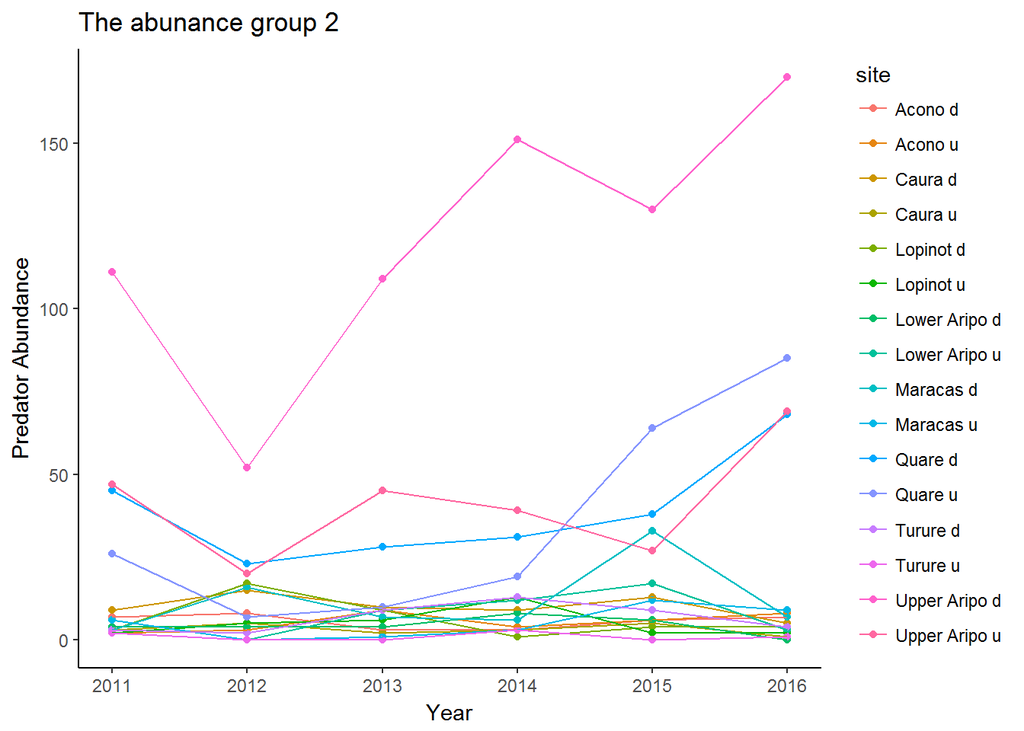

```r
AbPlotm <- ggplot(FishDataTotAbm, aes(x = Year, y = AbundanceSum, col = site, group = site))
AbPlotm + geom_point() +
    geom_line() +
    theme_classic() +
    labs(title="The abunance group 2", y = "Predator Abundance")
```

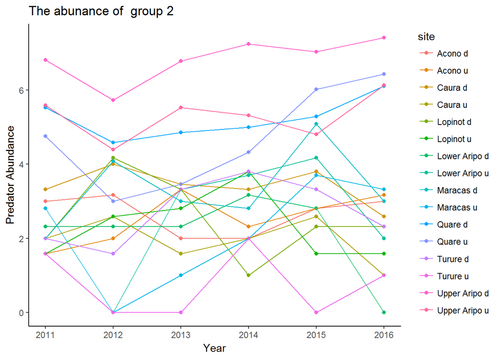

```r
AbPlotLogm <- ggplot(FishDataTotAbm, aes(x = Year, y = logAb, col = site, group = site))
AbPlotLogm + geom_point() +
    geom_line() +
    theme_classic() +
    labs(title="The abunance of  group 2", y = "Predator Abundance")
```

Next is the mixed model results and plot of slopes of the sites

```r
AbM1m <- lmer(logAb  ~ meanCentredYear + (meanCentredYear|site), data = FishDataTotAbm)
summary(AbM1m)
```

```
## Linear mixed model fit by REML ['lmerMod']
## Formula: logAb ~ meanCentredYear + (meanCentredYear | site)
##    Data: FishDataTotAbm
##
## REML criterion at convergence: 305.7
##
## Scaled residuals:
##     Min      1Q  Median      3Q     Max
## -2.8169 -0.6397  0.1097  0.6287  1.8608
##
## Random effects:
##  Groups   Name            Variance Std.Dev. Corr
##  site     (Intercept)     2.260414 1.50347
##           meanCentredYear 0.006954 0.08339  1.00
##  Residual                 0.865853 0.93051
## Number of obs: 96, groups:  site, 16
##
## Fixed effects:
##                 Estimate Std. Error t value
## (Intercept)      3.20148    0.38768   8.258
## meanCentredYear  0.09657    0.05939   1.626
##
## Correlation of Fixed Effects:
##             (Intr)
## meanCntrdYr 0.340
```

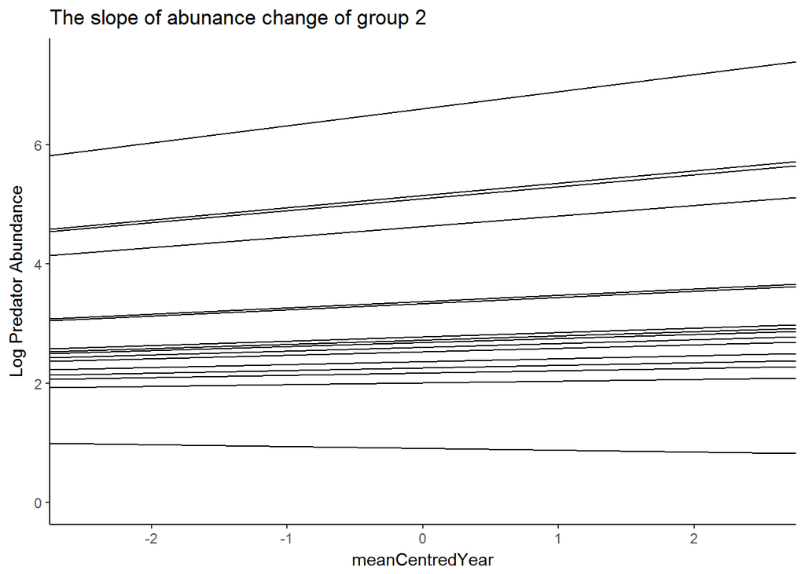

```r
#plot slopes of sites
AbM1_Linesm <- coef(AbM1m)$site[c(1:2)] # get slope and intercept of each line in model 3
names(AbM1_Linesm) <- c("intercept", "slope")

m3.plot <- ggplot(data = FishDataTotAbm, aes(x = meanCentredYear, y = logAb)) # plot of model with varying intercept but not slope, but only main slope shown
m3.plot + geom_blank() +
    theme_classic() +
    geom_abline(slope = AbM1_Linesm$slope, intercept = AbM1_Linesm$intercept) +
    labs(title="The slope of abunance change of group 2", y = "Log Predator Abundance")
```

## Wide level predation definition

Here is the plot showing trendlines for each sites, using the linear model part of ggplot

```r
predOrderb <- data.frame(FishDataTotAbw %>% #det the oder of which sites are highest predation for plotting
  group_by(site) %>%
  summarise(meanAb = mean(AbundanceSum)) %>%
  arrange(meanAb) %>%
  mutate(orderAb = c(1:16)))

plotNAbDataw <- merge(FishDataTotAbw, predOrderb, by = "site")

plotNAbDataw <- plotNAbDataw[order(plotNAbDataw$orderAb),]
plotNAbDataw$reoderedSite <- reorder(plotNAbDataw$site, plotNAbDataw$orderAb)

getPalette <-  colorRampPalette(c("blue", "red"))
getPalette(16)
```

```
##  [1] "#0000FF" "#1100EE" "#2200DD" "#3300CC" "#4400BB" "#5500AA" "#660099"
##  [8] "#770088" "#880077" "#990066" "#AA0055" "#BB0044" "#CC0032" "#DD0021"
## [15] "#EE0010" "#FF0000"
```

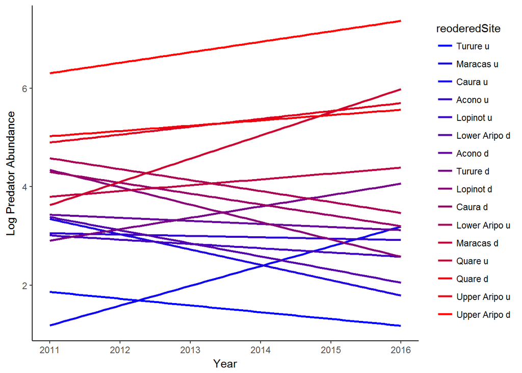

```r
MiddleAdundance <- ggplot(aes(x = Year, y = logAb, colour = reoderedSite),data = plotNAbDataw)
MiddleAdundance +
  geom_smooth(se = FALSE, method = "lm") +
    theme_classic()+
    labs(y = "Log Predator Abundance") +
  scale_colour_manual(values = getPalette(16))
```

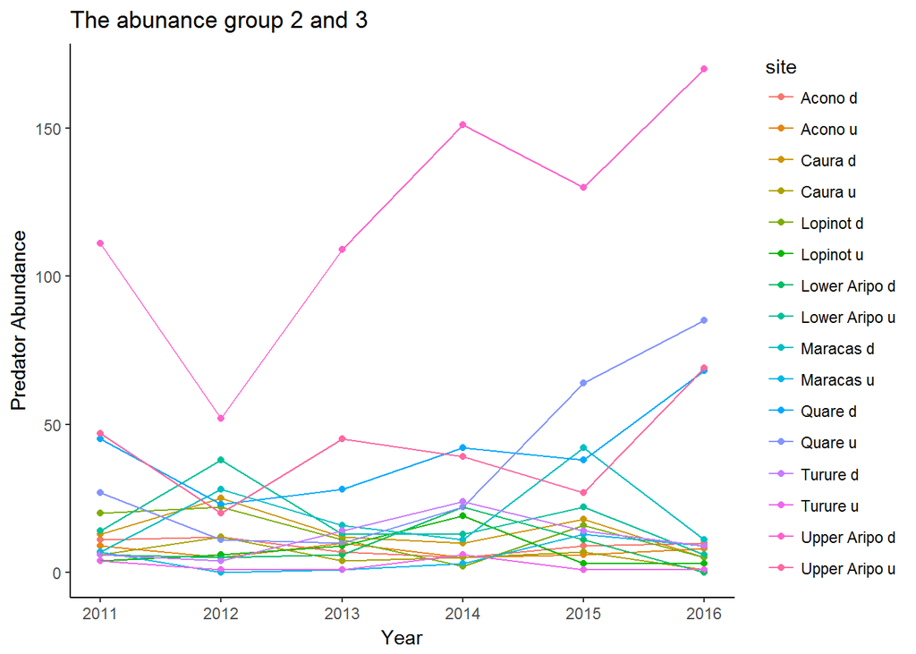

```r
AbPlotw <- ggplot(FishDataTotAbw, aes(x = Year, y = AbundanceSum, col = site, group = site))
AbPlotw + geom_point() +
    geom_line() +
    theme_classic() +
    labs(title="The abunance group 2 and 3", y = "Predator Abundance")
```

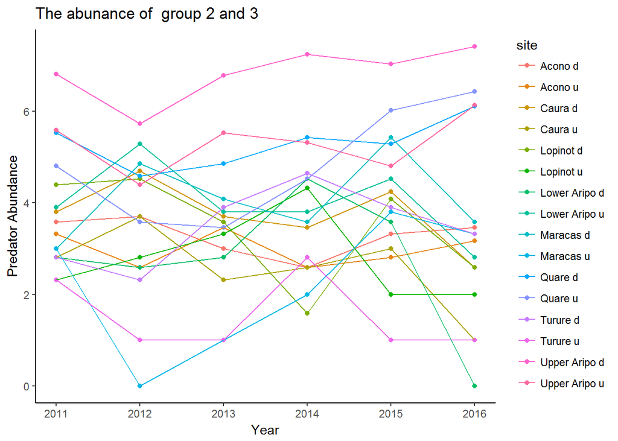

```r
AbPlotLogw <- ggplot(FishDataTotAbw, aes(x = Year, y = logAb, col = site, group = site))
AbPlotLogw + geom_point() +
    geom_line() +
    theme_classic() +
    labs(title="The abunance of  group 2 and 3", y = "Predator Abundance")
```

Next is the mixed model results and plot of slopes of the sites

```r
AbM1w <- lmer(logAb  ~ meanCentredYear + (meanCentredYear|site), data = FishDataTotAbw)
summary(AbM1w)
```

```
## Linear mixed model fit by REML ['lmerMod']
## Formula: logAb ~ meanCentredYear + (meanCentredYear | site)
##    Data: FishDataTotAbw
##
## REML criterion at convergence: 298
##
## Scaled residuals:
##      Min       1Q   Median       3Q      Max
## -2.79248 -0.57455  0.03564  0.63168  2.02632
##
## Random effects:
##  Groups   Name            Variance Std.Dev. Corr
##  site     (Intercept)     1.68474  1.2980
##           meanCentredYear 0.01742  0.1320   0.79
##  Residual                 0.80615  0.8979
## Number of obs: 96, groups:  site, 16
##
## Fixed effects:
##                  Estimate Std. Error t value
## (Intercept)     3.6934161  0.3371851  10.954
## meanCentredYear 0.0008493  0.0629897   0.013
##
## Correlation of Fixed Effects:
##             (Intr)
## meanCntrdYr 0.400
```

[figure not shown]

```r
#plot slopes of sites
AbM1_Linesw <- coef(AbM1w)$site[c(1:2)] # get slope and intercept of each line in model 3
names(AbM1_Linesw) <- c("intercept", "slope")

m3.plotw <- ggplot(data = FishDataTotAbw, aes(x = meanCentredYear, y = logAb)) # plot of model with varying intercept but not slope, but only main slope shown
m3.plot + geom_blank() +
    theme_classic() +
    geom_abline(slope = AbM1_Linesw$slope, intercept = AbM1_Linesw$intercept) +
    labs(title="The slope of abunance change of group 2", y = "Log Predator Abundance")
```